# Práctica calificada 6 - Parte II

## Ejercicio 5

1. Get a polygons map of the lowest administrative unit possible.
2. Get a table of variables for those units. At least 3 numerical variables.
3. Preprocess both tables and get them ready for merging.
4. Do the merging, making the changes needed so that you keep the most rows.

```python
from google.colab import drive
drive.mount('/content/drive')
```

```python
import os
import geopandas as gpd
gpd.list_layers(os.path.join("/content/drive/MyDrive/ICDE/maps/maps","canadaMaps_ESRI_102001.gpkg"))
```

|  | name | geometry_type |
| --- | --- | --- |
| 0 | border | MultiLineString |
| 1 | country | MultiPolygon |
| 2 | cities | Point |
| 3 | rivers | MultiLineString |
| 4 | centroid | Point |
| 5 | airports | Point |
| 6 | country_GADM | MultiPolygon |
| 7 | provincias_GADM | MultiPolygon |
| 8 | municipios_GADM | MultiPolygon |
| 9 | menor_GADM | MultiPolygon |
| 10 | indicators | MultiPolygon |

```python
country_GADM=gpd.read_file(os.path.join("/content/drive/MyDrive/ICDE/maps/maps","canadaMaps_ESRI_102001.gpkg"), layer='country_GADM')
provincias_GADM=gpd.read_file(os.path.join("/content/drive/MyDrive/ICDE/maps/maps","canadaMaps_ESRI_102001.gpkg"), layer='provincias_GADM')
```

```python
country_GADM
```

|  | GID_0 | COUNTRY | geometry |
| --- | --- | --- | --- |
| 0 | CAN | Canada | MULTIPOLYGON (((-1994097.1 1323442.596, -19940... |

```python
provincias_GADM
```

|  | GID_1 | GID_0 | COUNTRY | NAME_1 | VARNAME_1 | NL_NAME_1 | TYPE_1 | ENGTYPE_1 | CC_1 | HASC_1 | ISO_1 | geometry |
| --- | --- | --- | --- | --- | --- | --- | --- | --- | --- | --- | --- | --- |
| 0 | CAN.1_1 | CAN | Canada | Alberta | NA | NA | Province | Province | 48 | CA.AB | CA-AB | MULTIPOLYGON (((-1191696.513 1131094.24, -1193... |
| 1 | CAN.2_1 | CAN | Canada | British Columbia | Colombie britannique\|New Caledon | NA | Province | Province | 59 | CA.BC | CA-BC | MULTIPOLYGON (((-1994216.432 1323427.567, -199... |
| 2 | CAN.3_1 | CAN | Canada | Manitoba | NA | NA | Province | Province | 46 | CA.MB | CA-MB | MULTIPOLYGON (((-225729.524 989985.252, -22714... |
| 3 | CAN.4_1 | CAN | Canada | New Brunswick | Nouveau-Brunswick\|Acadia | NA | Province | Province | 13 | CA.NB | CA-NB | MULTIPOLYGON (((2280813.977 989844.48, 2280788... |
| 4 | CAN.5_1 | CAN | Canada | Newfoundland and Labrador | Newfoundland\|Terre-Neuve\|Terre-N | NA | Province | Province | 10 | CA.NF | CA-NL | MULTIPOLYGON (((3062487.374 1723165.753, 30624... |
| 5 | CAN.6_1 | CAN | Canada | Northwest Territories | Territoires du Nord-Ouest | NA | Territoire | Territory | 61 | CA.NT | CA-NT | MULTIPOLYGON (((-932976.987 3668489.676, -9330... |
| 6 | CAN.7_1 | CAN | Canada | Nova Scotia | Acadia\|Nouvelle-Écosse | NA | Province | Province | 12 | CA.NS | CA-NS | MULTIPOLYGON (((2419990.709 926493.096, 242000... |
| 7 | CAN.8_1 | CAN | Canada | Nunavut | NA | NA | Territoire | Territory | 62 | CA.NU | CA-NU | MULTIPOLYGON (((1581589.008 2742840.281, 15815... |
| 8 | CAN.9_1 | CAN | Canada | Ontario | Upper Canada | NA | Province | Province | 35 | CA.ON | CA-ON | MULTIPOLYGON (((1409005.46 492629.458, 1408574... |
| 9 | CAN.10_1 | CAN | Canada | Prince Edward Island | Île de Saint-Jean\|Île du Prince- | NA | Province | Province | 11 | CA.PE | CA-PE | MULTIPOLYGON (((2505095.555 1289997.862, 25051... |
| 10 | CAN.11_1 | CAN | Canada | Québec | Lower Canada | NA | Province | Province | 24 | CA.QC | NA | MULTIPOLYGON (((1678607.031 812858.207, 167861... |
| 11 | CAN.12_1 | CAN | Canada | Saskatchewan | NA | NA | Province | Province | 47 | CA.SK | CA-SK | MULTIPOLYGON (((-479648.471 1008211.632, -4796... |
| 12 | CAN.13_1 | CAN | Canada | Yukon | Yukon Territory\|Territoire du Yu | NA | Territoire | Territory | 60 | CA.YT | CA-YT | MULTIPOLYGON (((-1485495.114 2531187.928, -148... |

**IDH**

```python
import pandas as pd
linkIDH="https://en.wikipedia.org/wiki/List_of_Canadian_provinces_and_territories_by_Human_Development_Index"
IDH=pd.read_html(linkIDH)[0]
IDH
```

|  | Rank | Province or territory | HDI (2022)[1] |
| --- | --- | --- | --- |
| 0 | 1 | Alberta | 0.947 |
| 1 | 2 | British Columbia | 0.946 |
| 2 | 3 | Ontario | 0.942 |
| 3 | — | Canada (average) | 0.935 |
| 4 | 4 | Prince Edward Island | 0.929 |
| 5 | 4 | Northwest Territories | 0.929 |
| 6 | 4 | Yukon | 0.929 |
| 7 | 4 | Nunavut | 0.929 |
| 8 | 8 | Quebec | 0.926 |
| 9 | 9 | Saskatchewan | 0.920 |
| 10 | 10 | Nova Scotia | 0.909 |
| 11 | 11 | Manitoba | 0.907 |
| 12 | 12 | New Brunswick | 0.904 |
| 13 | 13 | Newfoundland and Labrador | 0.901 |

```python
IDH.drop(columns=['Rank'], inplace=True)
IDH.drop(index=3, inplace=True)
IDH.reset_index(drop=True, inplace=True)
IDH.rename(columns={'HDI (2022)[1]':'IDH_2022',"Province or territory":"PROVINCIA"}, inplace=True)
IDH['PROVINCIA']=IDH.PROVINCIA.str.upper()
IDH
```

|  | PROVINCIA | IDH_2022 |
| --- | --- | --- |
| 0 | ALBERTA | 0.947 |
| 1 | BRITISH COLUMBIA | 0.946 |
| 2 | ONTARIO | 0.942 |
| 3 | PRINCE EDWARD ISLAND | 0.929 |
| 4 | NORTHWEST TERRITORIES | 0.929 |
| 5 | YUKON | 0.929 |
| 6 | NUNAVUT | 0.929 |
| 7 | QUEBEC | 0.926 |
| 8 | SASKATCHEWAN | 0.920 |
| 9 | NOVA SCOTIA | 0.909 |
| 10 | MANITOBA | 0.907 |
| 11 | NEW BRUNSWICK | 0.904 |
| 12 | NEWFOUNDLAND AND LABRADOR | 0.901 |

```python
IDH.info()
```

```
<class 'pandas.core.frame.DataFrame'>
RangeIndex: 13 entries, 0 to 12
Data columns (total 2 columns):
 #   Column     Non-Null Count  Dtype
---  ------     --------------  -----
 0   PROVINCIA  13 non-null     object
 1   IDH_2022   13 non-null     float64
dtypes: float64(1), object(1)
memory usage: 340.0+ bytes
```

**PBI**

```python
linkPBI="https://en.wikipedia.org/wiki/List_of_Canadian_provinces_and_territories_by_gross_domestic_product"
PBI=pd.read_html(linkPBI)[0]      # se tendrá que trabjar con GDP per capita
PBI
```

|  | Province or territory | GDP (million CAD, 2023) | Share of national GDP (%, 2023) | Population (July 1, 2023) | GDP per capita (CAD, 2023) | Market income per capita (CAD, 2022) |
| --- | --- | --- | --- | --- | --- | --- |
| 0 | Canada | 2933810 | 100.00 | 40083484 | 73192 | 39741 |
| 1 | Alberta | 452410 | 15.42 | 4684514 | 96576 | 43434 |
| 2 | British Columbia | 409881 | 13.97 | 5531553 | 74099 | 42094 |
| 3 | Manitoba | 91872 | 3.13 | 1454743 | 63153 | 33057 |
| 4 | Newfoundland and Labrador | 38959 | 1.33 | 538907 | 72293 | 33871 |
| 5 | New Brunswick | 47035 | 1.60 | 832190 | 56520 | 32145 |
| 6 | Northwest Territories | 5478 | 0.19 | 44681 | 122602 | 47470 |
| 7 | Nova Scotia | 59574 | 2.03 | 1056486 | 56389 | 33866 |
| 8 | Nunavut | 4825 | 0.16 | 40700 | 118550 | 29475 |
| 9 | Ontario | 1119545 | 38.16 | 15623207 | 71659 | 40940 |
| 10 | Prince Edward Island | 9924 | 0.34 | 173713 | 57129 | 32329 |
| 11 | Quebec | 579460 | 19.75 | 8848020 | 65490 | 37819 |
| 12 | Saskatchewan | 109702 | 3.74 | 1209307 | 90715 | 35744 |
| 13 | Yukon | 4330 | 0.15 | 45463 | 95242 | 48232 |

```python
PBI.drop(columns=["GDP (million CAD, 2023)","Share of national GDP (%, 2023)","Market income per capita (CAD, 2022)"], inplace=True)
PBI.drop(index=0, inplace=True)
PBI.reset_index(drop=True, inplace=True)
PBI.rename(columns={'Population (July 1, 2023)':'Poblacion',"Province or  territory":"PROVINCIA","GDP per capita (CAD, 2023)":"GDPperCapita_2023"}, inplace=True)
PBI['PROVINCIA']=PBI.PROVINCIA.str.upper()
PBI
```

|  | PROVINCIA | Poblacion | GDPperCapita_2023 |
| --- | --- | --- | --- |
| 0 | ALBERTA | 4684514 | 96576 |
| 1 | BRITISH COLUMBIA | 5531553 | 74099 |
| 2 | MANITOBA | 1454743 | 63153 |
| 3 | NEWFOUNDLAND AND LABRADOR | 538907 | 72293 |
| 4 | NEW BRUNSWICK | 832190 | 56520 |
| 5 | NORTHWEST TERRITORIES | 44681 | 122602 |
| 6 | NOVA SCOTIA | 1056486 | 56389 |
| 7 | NUNAVUT | 40700 | 118550 |
| 8 | ONTARIO | 15623207 | 71659 |
| 9 | PRINCE EDWARD ISLAND | 173713 | 57129 |
| 10 | QUEBEC | 8848020 | 65490 |
| 11 | SASKATCHEWAN | 1209307 | 90715 |
| 12 | YUKON | 45463 | 95242 |

**homicide rate**

```python
linkHomRate="https://en.wikipedia.org/wiki/List_of_Canadian_provinces_and_territories_by_homicide_rate"
HomRate=pd.read_html(linkHomRate)[0]
HomRate
```

|  | Province/territory | 1990 | 2000 | 2010 | 2015 | 2016 | 2017 | 2018 | 2019 | 2020 | 2021 | 2022 | 2023 | 2015 –2023 |
| --- | --- | --- | --- | --- | --- | --- | --- | --- | --- | --- | --- | --- | --- | --- |
| 0 | Ontario | 1.77 | 1.35 | 1.44 | 1.27 | 1.48 | 1.41 | 1.90 | 1.74 | 1.65 | 1.91 | 1.93 | 1.68 | 1.66 |
| 1 | Quebec | 2.63 | 2.00 | 1.08 | 0.97 | 0.81 | 1.12 | 1.00 | 0.92 | 1.02 | 1.05 | 1.28 | 1.14 | 1.03 |
| 2 | British Columbia | 3.34 | 2.10 | 1.86 | 2.01 | 1.85 | 2.45 | 1.83 | 1.78 | 1.93 | 2.39 | 2.89 | 2.23 | 2.15 |
| 3 | Alberta | 3.20 | 1.96 | 2.09 | 3.21 | 2.76 | 2.81 | 1.93 | 2.30 | 3.24 | 2.69 | 2.64 | 2.45 | 2.67 |
| 4 | Manitoba | 3.44 | 2.61 | 3.69 | 3.71 | 3.27 | 3.52 | 4.07 | 5.40 | 4.49 | 4.45 | 6.30 | 5.09 | 4.48 |
| 5 | Saskatchewan | 3.57 | 2.58 | 3.23 | 4.10 | 5.02 | 3.31 | 3.03 | 4.72 | 5.48 | 6.08 | 6.19 | 4.88 | 4.76 |
| 6 | Nova Scotia | 0.88 | 1.71 | 2.34 | 1.28 | 1.38 | 2.21 | 1.14 | 0.61 | 3.74[n 1] | 2.30 | 1.85 | 1.32 | 1.86 |
| 7 | New Brunswick | 1.49 | 1.33 | 1.20 | 1.45 | 1.44 | 1.30 | 1.69 | 2.19 | 1.79 | 1.39 | 1.85 | 1.08 | 1.58 |
| 8 | Newfoundland and Labrador | 0.00 | 1.14 | 0.77 | 0.57 | 1.51 | 0.76 | 0.38 | 0.95 | 0.76 | 1.52 | 0.56 | 1.49 | 0.94 |
| 9 | Prince Edward Island | 0.77 | 2.20 | 0.00 | 0.69 | 0.00 | 1.34 | 0.00 | 1.28 | 0.63 | 0.62 | 0.00 | 0.58 | 0.72 |
| 10 | Northwest Territories | 20.40 | 2.47 | 2.31 | 13.56 | 6.72 | 4.48 | 13.47 | 4.50 | 13.48 | 2.24 | 6.71 | 13.34 | 7.32 |
| 11 | Yukon | 3.60 | 6.57 | 2.89 | 2.65 | 10.38 | 20.24 | 7.43 | 2.43 | 0.00 | 9.31 | 4.56 | 8.89 | 7.32 |
| 12 | Nunavut | NaN | 10.91 | 17.99 | 5.48 | 2.70 | 15.93 | 20.88 | 18.02 | 7.60 | 4.99 | 2.47 | 4.92 | 9.22 |

```python
HOMRATE=HomRate.loc[:,["Province/territory","2023"]]
HOMRATE
```

|  | Province/territory | 2023 |
| --- | --- | --- |
| 0 | Ontario | 1.68 |
| 1 | Quebec | 1.14 |
| 2 | British Columbia | 2.23 |
| 3 | Alberta | 2.45 |
| 4 | Manitoba | 5.09 |
| 5 | Saskatchewan | 4.88 |
| 6 | Nova Scotia | 1.32 |
| 7 | New Brunswick | 1.08 |
| 8 | Newfoundland and Labrador | 1.49 |
| 9 | Prince Edward Island | 0.58 |
| 10 | Northwest Territories | 13.34 |
| 11 | Yukon | 8.89 |
| 12 | Nunavut | 4.92 |

```python
HOMRATE.rename(columns={'Province/territory':'PROVINCIA',"2023":"HomicideRate_2023"}, inplace=True)
HOMRATE['PROVINCIA']=HOMRATE.PROVINCIA.str.upper()
HOMRATE
```

|  | PROVINCIA | HomicideRate_2023 |
| --- | --- | --- |
| 0 | ONTARIO | 1.68 |
| 1 | QUEBEC | 1.14 |
| 2 | BRITISH COLUMBIA | 2.23 |
| 3 | ALBERTA | 2.45 |
| 4 | MANITOBA | 5.09 |
| 5 | SASKATCHEWAN | 4.88 |
| 6 | NOVA SCOTIA | 1.32 |
| 7 | NEW BRUNSWICK | 1.08 |
| 8 | NEWFOUNDLAND AND LABRADOR | 1.49 |
| 9 | PRINCE EDWARD ISLAND | 0.58 |
| 10 | NORTHWEST TERRITORIES | 13.34 |
| 11 | YUKON | 8.89 |
| 12 | NUNAVUT | 4.92 |

```python
# se hace merge entre los 3 DF
IDH_PBI=pd.merge(IDH,PBI, on='PROVINCIA')
dataVariables=pd.merge(IDH_PBI,HOMRATE, on='PROVINCIA')
dataVariables
```

|  | PROVINCIA | IDH_2022 | Poblacion | GDPperCapita_2023 | HomicideRate_2023 |
| --- | --- | --- | --- | --- | --- |
| 0 | ALBERTA | 0.947 | 4684514 | 96576 | 2.45 |
| 1 | BRITISH COLUMBIA | 0.946 | 5531553 | 74099 | 2.23 |
| 2 | ONTARIO | 0.942 | 15623207 | 71659 | 1.68 |
| 3 | PRINCE EDWARD ISLAND | 0.929 | 173713 | 57129 | 0.58 |
| 4 | NORTHWEST TERRITORIES | 0.929 | 44681 | 122602 | 13.34 |
| 5 | YUKON | 0.929 | 45463 | 95242 | 8.89 |
| 6 | NUNAVUT | 0.929 | 40700 | 118550 | 4.92 |
| 7 | QUEBEC | 0.926 | 8848020 | 65490 | 1.14 |
| 8 | SASKATCHEWAN | 0.920 | 1209307 | 90715 | 4.88 |
| 9 | NOVA SCOTIA | 0.909 | 1056486 | 56389 | 1.32 |
| 10 | MANITOBA | 0.907 | 1454743 | 63153 | 5.09 |
| 11 | NEW BRUNSWICK | 0.904 | 832190 | 56520 | 1.08 |
| 12 | NEWFOUNDLAND AND LABRADOR | 0.901 | 538907 | 72293 | 1.49 |

```python
provincias_GADM
```

|  | GID_1 | GID_0 | COUNTRY | NAME_1 | VARNAME_1 | NL_NAME_1 | TYPE_1 | ENGTYPE_1 | CC_1 | HASC_1 | ISO_1 | geometry |
| --- | --- | --- | --- | --- | --- | --- | --- | --- | --- | --- | --- | --- |
| 0 | CAN.1_1 | CAN | Canada | Alberta | NA | NA | Province | Province | 48 | CA.AB | CA-AB | MULTIPOLYGON (((-1191696.513 1131094.24, -1193... |
| 1 | CAN.2_1 | CAN | Canada | British Columbia | Colombie britannique\|New Caledon | NA | Province | Province | 59 | CA.BC | CA-BC | MULTIPOLYGON (((-1994216.432 1323427.567, -199... |
| 2 | CAN.3_1 | CAN | Canada | Manitoba | NA | NA | Province | Province | 46 | CA.MB | CA-MB | MULTIPOLYGON (((-225729.524 989985.252, -22714... |
| 3 | CAN.4_1 | CAN | Canada | New Brunswick | Nouveau-Brunswick\|Acadia | NA | Province | Province | 13 | CA.NB | CA-NB | MULTIPOLYGON (((2280813.977 989844.48, 2280788... |
| 4 | CAN.5_1 | CAN | Canada | Newfoundland and Labrador | Newfoundland\|Terre-Neuve\|Terre-N | NA | Province | Province | 10 | CA.NF | CA-NL | MULTIPOLYGON (((3062487.374 1723165.753, 30624... |
| 5 | CAN.6_1 | CAN | Canada | Northwest Territories | Territoires du Nord-Ouest | NA | Territoire | Territory | 61 | CA.NT | CA-NT | MULTIPOLYGON (((-932976.987 3668489.676, -9330... |
| 6 | CAN.7_1 | CAN | Canada | Nova Scotia | Acadia\|Nouvelle-Écosse | NA | Province | Province | 12 | CA.NS | CA-NS | MULTIPOLYGON (((2419990.709 926493.096, 242000... |
| 7 | CAN.8_1 | CAN | Canada | Nunavut | NA | NA | Territoire | Territory | 62 | CA.NU | CA-NU | MULTIPOLYGON (((1581589.008 2742840.281, 15815... |
| 8 | CAN.9_1 | CAN | Canada | Ontario | Upper Canada | NA | Province | Province | 35 | CA.ON | CA-ON | MULTIPOLYGON (((1409005.46 492629.458, 1408574... |
| 9 | CAN.10_1 | CAN | Canada | Prince Edward Island | Île de Saint-Jean\|Île du Prince- | NA | Province | Province | 11 | CA.PE | CA-PE | MULTIPOLYGON (((2505095.555 1289997.862, 25051... |
| 10 | CAN.11_1 | CAN | Canada | Québec | Lower Canada | NA | Province | Province | 24 | CA.QC | NA | MULTIPOLYGON (((1678607.031 812858.207, 167861... |
| 11 | CAN.12_1 | CAN | Canada | Saskatchewan | NA | NA | Province | Province | 47 | CA.SK | CA-SK | MULTIPOLYGON (((-479648.471 1008211.632, -4796... |
| 12 | CAN.13_1 | CAN | Canada | Yukon | Yukon Territory\|Territoire du Yu | NA | Territoire | Territory | 60 | CA.YT | CA-YT | MULTIPOLYGON (((-1485495.114 2531187.928, -148... |

```python
provincias_GADM.columns.to_list()
```

```
['GID_1',
 'GID_0',
 'COUNTRY',
 'NAME_1',
 'VARNAME_1',
 'NL_NAME_1',
 'TYPE_1',
 'ENGTYPE_1',
 'CC_1',
 'HASC_1',
 'ISO_1',
 'geometry']
```

```python
# nos quedamos con las columnas importantes
provinciasGeometria=provincias_GADM.loc[:,['COUNTRY','NAME_1','geometry']]
provinciasGeometria
```

|  | COUNTRY | NAME_1 | geometry |
| --- | --- | --- | --- |
| 0 | Canada | Alberta | MULTIPOLYGON (((-1191696.513 1131094.24, -1193... |
| 1 | Canada | British Columbia | MULTIPOLYGON (((-1994216.432 1323427.567, -199... |
| 2 | Canada | Manitoba | MULTIPOLYGON (((-225729.524 989985.252, -22714... |
| 3 | Canada | New Brunswick | MULTIPOLYGON (((2280813.977 989844.48, 2280788... |
| 4 | Canada | Newfoundland and Labrador | MULTIPOLYGON (((3062487.374 1723165.753, 30624... |
| 5 | Canada | Northwest Territories | MULTIPOLYGON (((-932976.987 3668489.676, -9330... |
| 6 | Canada | Nova Scotia | MULTIPOLYGON (((2419990.709 926493.096, 242000... |
| 7 | Canada | Nunavut | MULTIPOLYGON (((1581589.008 2742840.281, 15815... |
| 8 | Canada | Ontario | MULTIPOLYGON (((1409005.46 492629.458, 1408574... |
| 9 | Canada | Prince Edward Island | MULTIPOLYGON (((2505095.555 1289997.862, 25051... |
| 10 | Canada | Québec | MULTIPOLYGON (((1678607.031 812858.207, 167861... |
| 11 | Canada | Saskatchewan | MULTIPOLYGON (((-479648.471 1008211.632, -4796... |
| 12 | Canada | Yukon | MULTIPOLYGON (((-1485495.114 2531187.928, -148... |

```python
provinciasGeometria.rename(columns={"NAME_1":"PROVINCIA"}, inplace=True)
provinciasGeometria['PROVINCIA']=provinciasGeometria.PROVINCIA.str.upper()
provinciasGeometria['COUNTRY']=provinciasGeometria.COUNTRY.str.upper()
provinciasGeometria.loc[10,"PROVINCIA"]='QUEBEC'
provinciasGeometria
```

|  | COUNTRY | PROVINCIA | geometry |
| --- | --- | --- | --- |
| 0 | CANADA | ALBERTA | MULTIPOLYGON (((-1191696.513 1131094.24, -1193... |
| 1 | CANADA | BRITISH COLUMBIA | MULTIPOLYGON (((-1994216.432 1323427.567, -199... |
| 2 | CANADA | MANITOBA | MULTIPOLYGON (((-225729.524 989985.252, -22714... |
| 3 | CANADA | NEW BRUNSWICK | MULTIPOLYGON (((2280813.977 989844.48, 2280788... |
| 4 | CANADA | NEWFOUNDLAND AND LABRADOR | MULTIPOLYGON (((3062487.374 1723165.753, 30624... |
| 5 | CANADA | NORTHWEST TERRITORIES | MULTIPOLYGON (((-932976.987 3668489.676, -9330... |
| 6 | CANADA | NOVA SCOTIA | MULTIPOLYGON (((2419990.709 926493.096, 242000... |
| 7 | CANADA | NUNAVUT | MULTIPOLYGON (((1581589.008 2742840.281, 15815... |
| 8 | CANADA | ONTARIO | MULTIPOLYGON (((1409005.46 492629.458, 1408574... |
| 9 | CANADA | PRINCE EDWARD ISLAND | MULTIPOLYGON (((2505095.555 1289997.862, 25051... |
| 10 | CANADA | QUEBEC | MULTIPOLYGON (((1678607.031 812858.207, 167861... |
| 11 | CANADA | SASKATCHEWAN | MULTIPOLYGON (((-479648.471 1008211.632, -4796... |
| 12 | CANADA | YUKON | MULTIPOLYGON (((-1485495.114 2531187.928, -148... |

```python
# finalmente se hace merge para tener la geometría y las variables en un solo GDF
data=pd.merge(provinciasGeometria,dataVariables, on='PROVINCIA')
data
```

|  | COUNTRY | PROVINCIA | geometry | IDH_2022 | Poblacion | GDPperCapita_2023 | HomicideRate_2023 |
| --- | --- | --- | --- | --- | --- | --- | --- |
| 0 | CANADA | ALBERTA | MULTIPOLYGON (((-1191696.513 1131094.24, -1193... | 0.947 | 4684514 | 96576 | 2.45 |
| 1 | CANADA | BRITISH COLUMBIA | MULTIPOLYGON (((-1994216.432 1323427.567, -199... | 0.946 | 5531553 | 74099 | 2.23 |
| 2 | CANADA | MANITOBA | MULTIPOLYGON (((-225729.524 989985.252, -22714... | 0.907 | 1454743 | 63153 | 5.09 |
| 3 | CANADA | NEW BRUNSWICK | MULTIPOLYGON (((2280813.977 989844.48, 2280788... | 0.904 | 832190 | 56520 | 1.08 |
| 4 | CANADA | NEWFOUNDLAND AND LABRADOR | MULTIPOLYGON (((3062487.374 1723165.753, 30624... | 0.901 | 538907 | 72293 | 1.49 |
| 5 | CANADA | NORTHWEST TERRITORIES | MULTIPOLYGON (((-932976.987 3668489.676, -9330... | 0.929 | 44681 | 122602 | 13.34 |
| 6 | CANADA | NOVA SCOTIA | MULTIPOLYGON (((2419990.709 926493.096, 242000... | 0.909 | 1056486 | 56389 | 1.32 |
| 7 | CANADA | NUNAVUT | MULTIPOLYGON (((1581589.008 2742840.281, 15815... | 0.929 | 40700 | 118550 | 4.92 |
| 8 | CANADA | ONTARIO | MULTIPOLYGON (((1409005.46 492629.458, 1408574... | 0.942 | 15623207 | 71659 | 1.68 |
| 9 | CANADA | PRINCE EDWARD ISLAND | MULTIPOLYGON (((2505095.555 1289997.862, 25051... | 0.929 | 173713 | 57129 | 0.58 |
| 10 | CANADA | QUEBEC | MULTIPOLYGON (((1678607.031 812858.207, 167861... | 0.926 | 8848020 | 65490 | 1.14 |
| 11 | CANADA | SASKATCHEWAN | MULTIPOLYGON (((-479648.471 1008211.632, -4796... | 0.920 | 1209307 | 90715 | 4.88 |
| 12 | CANADA | YUKON | MULTIPOLYGON (((-1485495.114 2531187.928, -148... | 0.929 | 45463 | 95242 | 8.89 |

## Ejercicio 6

Compute the neighbors of the capital city of your country. Plot the results for each of the options.

```python
# buscar vecinos de las 3 maneras, pero luego decido con cuál quedarme
```

```python
#rojo es capital y amarillo son distritos
```

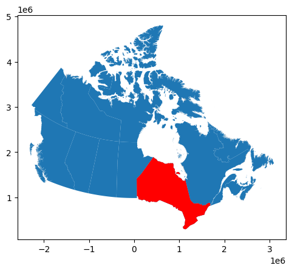

```python
base=data.plot()
data[data.PROVINCIA=='ONTARIO'].plot(ax=base, color='red')
```

```python
!pip install folium matplotlib mapclassify
```

```python
menor_GADM=gpd.read_file(os.path.join("/content/drive/MyDrive/ICDE/maps/maps","canadaMaps_ESRI_102001.gpkg"), layer='menor_GADM')
menor_GADM.head()
```

|  | GID_3 | GID_0 | COUNTRY | GID_1 | NAME_1 | NL_NAME_1 | GID_2 | NAME_2 | NL_NAME_2 | NAME_3 | VARNAME_3 | NL_NAME_3 | TYPE_3 | ENGTYPE_3 | CC_3 | HASC_3 | geometry |
| --- | --- | --- | --- | --- | --- | --- | --- | --- | --- | --- | --- | --- | --- | --- | --- | --- | --- |
| 0 | CAN.1.11.1_1 | CAN | Canada | CAN.1_1 | Alberta | NA | CAN.1.11_1 | Division No. 1 | NA | Bow Island | NA | NA | Town | Town | NA | NA | MULTIPOLYGON (((-1095252.637 1208455.549, -109... |
| 1 | CAN.1.11.2_1 | CAN | Canada | CAN.1_1 | Alberta | NA | CAN.1.11_1 | Division No. 1 | NA | Burdett | NA | NA | Village | Village | NA | NA | MULTIPOLYGON (((-1106734.051 1207041.712, -110... |
| 2 | CAN.1.11.3_1 | CAN | Canada | CAN.1_1 | Alberta | NA | CAN.1.11_1 | Division No. 1 | NA | Cypress County | NA | NA | Municipal District | Municipal District | NA | NA | MULTIPOLYGON (((-1114033.57 1214677.478, -1114... |
| 3 | CAN.1.11.4_1 | CAN | Canada | CAN.1_1 | Alberta | NA | CAN.1.11_1 | Division No. 1 | NA | Foremost | NA | NA | Village | Village | NA | NA | MULTIPOLYGON (((-1110213.091 1166590.676, -111... |
| 4 | CAN.1.11.5_1 | CAN | Canada | CAN.1_1 | Alberta | NA | CAN.1.11_1 | Division No. 1 | NA | Forty Mile County No. 8 | NA | NA | County Municipality | County Municipality | NA | NA | MULTIPOLYGON (((-1114033.57 1214677.478, -1113... |

```python
# en este caso, se trabajará con la capa con las geometrías más pequeñas, no con el GDF trabajado en la anterior actividad
from libpysal.weights import Queen, Rook, KNN

# rook
w_rook = Rook.from_dataframe(menor_GADM,use_index=False)
```

```python
w_queen = Queen.from_dataframe(menor_GADM,use_index=False)
```

```python
w_knn20 = KNN.from_dataframe(menor_GADM, k=20)
```

```python
menor_GADM[menor_GADM.NAME_2=="Ottawa"]
```

|  | GID_3 | GID_0 | COUNTRY | GID_1 | NAME_1 | NL_NAME_1 | GID_2 | NAME_2 | NL_NAME_2 | NAME_3 | VARNAME_3 | NL_NAME_3 | TYPE_3 | ENGTYPE_3 | CC_3 | HASC_3 | geometry |
| --- | --- | --- | --- | --- | --- | --- | --- | --- | --- | --- | --- | --- | --- | --- | --- | --- | --- |
| 2713 | CAN.9.35.1_1 | CAN | Canada | CAN.9_1 | Ontario | NA | CAN.9.35_1 | Ottawa | NA | Ottawa | NA | NA | Cité | City | NA | NA | MULTIPOLYGON (((1576105.437 788452.556, 157618... |

**rook**

```python
menor_GADM.iloc[w_rook.neighbors[2713] ,]
```

|  | GID_3 | GID_0 | COUNTRY | GID_1 | NAME_1 | NL_NAME_1 | GID_2 | NAME_2 | NL_NAME_2 | NAME_3 | VARNAME_3 | NL_NAME_3 | TYPE_3 | ENGTYPE_3 | CC_3 | HASC_3 | geometry |
| --- | --- | --- | --- | --- | --- | --- | --- | --- | --- | --- | --- | --- | --- | --- | --- | --- | --- |
| 2819 | CAN.9.44.13_1 | CAN | Canada | CAN.9_1 | Ontario | NA | CAN.9.44_1 | Renfrew | NA | McNab/Braeside | NA | NA | Township | Township | NA | NA | MULTIPOLYGON (((1534436.789 813992.934, 153416... |
| 2628 | CAN.9.27.9_1 | CAN | Canada | CAN.9_1 | Ontario | NA | CAN.9.27_1 | Leeds and Grenville | NA | Merrickville-Wolford | NA | NA | Village | Village | NA | NA | MULTIPOLYGON (((1578566.446 768358.064, 157863... |
| 2629 | CAN.9.27.10_1 | CAN | Canada | CAN.9_1 | Ontario | NA | CAN.9.27_1 | Leeds and Grenville | NA | North Grenville | NA | NA | Township | Township | NA | NA | MULTIPOLYGON (((1605927.213 775203.269, 160548... |
| 4298 | CAN.11.85.9_1 | CAN | Canada | CAN.11_1 | Québec | NA | CAN.11.85_1 | Papineau | NA | Lochaber-Partie-Ouest | NA | NA | Municipalité De Canton | Canton Municipality | NA | NA | MULTIPOLYGON (((1607168.778 851571.936, 160696... |
| 3346 | CAN.11.19.1_1 | CAN | Canada | CAN.11_1 | Québec | NA | CAN.11.19_1 | Communauté-Urbaine-de-l'Outaouai | NA | Aylmer | NA | NA | Ville | Ville | NA | NA | MULTIPOLYGON (((1580023.424 828702.304, 157996... |
| 3348 | CAN.11.19.3_1 | CAN | Canada | CAN.11_1 | Québec | NA | CAN.11.19_1 | Communauté-Urbaine-de-l'Outaouai | NA | Gatineau | NA | NA | Ville | Ville | NA | NA | MULTIPOLYGON (((1594697.151 843000.144, 159457... |
| 3349 | CAN.11.19.4_1 | CAN | Canada | CAN.11_1 | Québec | NA | CAN.11.19_1 | Communauté-Urbaine-de-l'Outaouai | NA | Hull | NA | NA | Ville | Ville | NA | NA | MULTIPOLYGON (((1583424.937 834159.215, 158329... |
| 3350 | CAN.11.19.5_1 | CAN | Canada | CAN.11_1 | Québec | NA | CAN.11.19_1 | Communauté-Urbaine-de-l'Outaouai | NA | Masson-Angers | NA | NA | Ville | Ville | NA | NA | MULTIPOLYGON (((1606967.254 851487.278, 160681... |
| 2776 | CAN.9.41.4_1 | CAN | Canada | CAN.9_1 | Ontario | NA | CAN.9.41_1 | Prescott and Russell | NA | Clarence-Rockland | NA | NA | Cité | City | NA | NA | MULTIPOLYGON (((1620148.048 835829.62, 1620096... |
| 2779 | CAN.9.41.7_1 | CAN | Canada | CAN.9_1 | Ontario | NA | CAN.9.41_1 | Prescott and Russell | NA | Russell | NA | NA | Township | Township | NA | NA | MULTIPOLYGON (((1618149.828 814194.153, 161786... |
| 2780 | CAN.9.41.8_1 | CAN | Canada | CAN.9_1 | Ontario | NA | CAN.9.41_1 | Prescott and Russell | NA | The Nation Municipality | NA | NA | Township | Township | NA | NA | MULTIPOLYGON (((1618798.831 834437.131, 161879... |
| 2848 | CAN.9.46.3_1 | CAN | Canada | CAN.9_1 | Ontario | NA | CAN.9.46_1 | Stormont, Dundas and Glengarry | NA | North Dundas | NA | NA | Township | Township | NA | NA | MULTIPOLYGON (((1615543.723 787415.214, 161553... |
| 2616 | CAN.9.26.6_1 | CAN | Canada | CAN.9_1 | Ontario | NA | CAN.9.26_1 | Lanark | NA | Mississippi Mills | NA | NA | Town | Town | NA | NA | MULTIPOLYGON (((1562965.857 798093.91, 1562154... |
| 3951 | CAN.11.63.6_1 | CAN | Canada | CAN.11_1 | Québec | NA | CAN.11.63_1 | Les Collines-de-l'Outaouais | NA | Pontiac | NA | NA | Municipalité | Municipality | NA | NA | MULTIPOLYGON (((1569848.222 824350.784, 156983... |
| 2612 | CAN.9.26.2_1 | CAN | Canada | CAN.9_1 | Ontario | NA | CAN.9.26_1 | Lanark | NA | Beckwith | NA | NA | Township | Township | NA | NA | MULTIPOLYGON (((1558157.764 790253.978, 155845... |
| 2808 | CAN.9.44.2_1 | CAN | Canada | CAN.9_1 | Ontario | NA | CAN.9.44_1 | Renfrew | NA | Arnprior | NA | NA | Town | Town | NA | NA | MULTIPOLYGON (((1534795.84 814658.656, 1534728... |
| 2617 | CAN.9.26.7_1 | CAN | Canada | CAN.9_1 | Ontario | NA | CAN.9.26_1 | Lanark | NA | Montague | NA | NA | Township | Township | NA | NA | MULTIPOLYGON (((1568113.605 775753.877, 156811... |

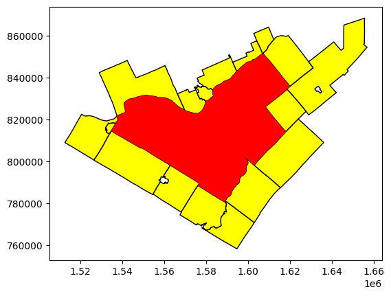

```python
# para metodo rook
base=menor_GADM.iloc[w_rook.neighbors[2713],].plot(facecolor="yellow",edgecolor='k')
menor_GADM.loc[menor_GADM.NAME_2=='Ottawa'].plot(ax=base,facecolor="red")
```

**queen**

```python
menor_GADM.iloc[w_queen.neighbors[2713] ,]
```

|  | GID_3 | GID_0 | COUNTRY | GID_1 | NAME_1 | NL_NAME_1 | GID_2 | NAME_2 | NL_NAME_2 | NAME_3 | VARNAME_3 | NL_NAME_3 | TYPE_3 | ENGTYPE_3 | CC_3 | HASC_3 | geometry |
| --- | --- | --- | --- | --- | --- | --- | --- | --- | --- | --- | --- | --- | --- | --- | --- | --- | --- |
| 2819 | CAN.9.44.13_1 | CAN | Canada | CAN.9_1 | Ontario | NA | CAN.9.44_1 | Renfrew | NA | McNab/Braeside | NA | NA | Township | Township | NA | NA | MULTIPOLYGON (((1534436.789 813992.934, 153416... |
| 2628 | CAN.9.27.9_1 | CAN | Canada | CAN.9_1 | Ontario | NA | CAN.9.27_1 | Leeds and Grenville | NA | Merrickville-Wolford | NA | NA | Village | Village | NA | NA | MULTIPOLYGON (((1578566.446 768358.064, 157863... |
| 2629 | CAN.9.27.10_1 | CAN | Canada | CAN.9_1 | Ontario | NA | CAN.9.27_1 | Leeds and Grenville | NA | North Grenville | NA | NA | Township | Township | NA | NA | MULTIPOLYGON (((1605927.213 775203.269, 160548... |
| 4298 | CAN.11.85.9_1 | CAN | Canada | CAN.11_1 | Québec | NA | CAN.11.85_1 | Papineau | NA | Lochaber-Partie-Ouest | NA | NA | Municipalité De Canton | Canton Municipality | NA | NA | MULTIPOLYGON (((1607168.778 851571.936, 160696... |
| 3346 | CAN.11.19.1_1 | CAN | Canada | CAN.11_1 | Québec | NA | CAN.11.19_1 | Communauté-Urbaine-de-l'Outaouai | NA | Aylmer | NA | NA | Ville | Ville | NA | NA | MULTIPOLYGON (((1580023.424 828702.304, 157996... |
| 3348 | CAN.11.19.3_1 | CAN | Canada | CAN.11_1 | Québec | NA | CAN.11.19_1 | Communauté-Urbaine-de-l'Outaouai | NA | Gatineau | NA | NA | Ville | Ville | NA | NA | MULTIPOLYGON (((1594697.151 843000.144, 159457... |
| 3349 | CAN.11.19.4_1 | CAN | Canada | CAN.11_1 | Québec | NA | CAN.11.19_1 | Communauté-Urbaine-de-l'Outaouai | NA | Hull | NA | NA | Ville | Ville | NA | NA | MULTIPOLYGON (((1583424.937 834159.215, 158329... |
| 3350 | CAN.11.19.5_1 | CAN | Canada | CAN.11_1 | Québec | NA | CAN.11.19_1 | Communauté-Urbaine-de-l'Outaouai | NA | Masson-Angers | NA | NA | Ville | Ville | NA | NA | MULTIPOLYGON (((1606967.254 851487.278, 160681... |
| 2776 | CAN.9.41.4_1 | CAN | Canada | CAN.9_1 | Ontario | NA | CAN.9.41_1 | Prescott and Russell | NA | Clarence-Rockland | NA | NA | Cité | City | NA | NA | MULTIPOLYGON (((1620148.048 835829.62, 1620096... |
| 4315 | CAN.11.86.2_1 | CAN | Canada | CAN.11_1 | Québec | NA | CAN.11.86_1 | Pontiac | NA | Bristol | NA | NA | Municipalité De Canton | Canton Municipality | NA | NA | MULTIPOLYGON (((1537464.461 821648.713, 153672... |
| 2780 | CAN.9.41.8_1 | CAN | Canada | CAN.9_1 | Ontario | NA | CAN.9.41_1 | Prescott and Russell | NA | The Nation Municipality | NA | NA | Township | Township | NA | NA | MULTIPOLYGON (((1618798.831 834437.131, 161879... |
| 2779 | CAN.9.41.7_1 | CAN | Canada | CAN.9_1 | Ontario | NA | CAN.9.41_1 | Prescott and Russell | NA | Russell | NA | NA | Township | Township | NA | NA | MULTIPOLYGON (((1618149.828 814194.153, 161786... |
| 2848 | CAN.9.46.3_1 | CAN | Canada | CAN.9_1 | Ontario | NA | CAN.9.46_1 | Stormont, Dundas and Glengarry | NA | North Dundas | NA | NA | Township | Township | NA | NA | MULTIPOLYGON (((1615543.723 787415.214, 161553... |
| 3951 | CAN.11.63.6_1 | CAN | Canada | CAN.11_1 | Québec | NA | CAN.11.63_1 | Les Collines-de-l'Outaouais | NA | Pontiac | NA | NA | Municipalité | Municipality | NA | NA | MULTIPOLYGON (((1569848.222 824350.784, 156983... |
| 2808 | CAN.9.44.2_1 | CAN | Canada | CAN.9_1 | Ontario | NA | CAN.9.44_1 | Renfrew | NA | Arnprior | NA | NA | Town | Town | NA | NA | MULTIPOLYGON (((1534795.84 814658.656, 1534728... |
| 2612 | CAN.9.26.2_1 | CAN | Canada | CAN.9_1 | Ontario | NA | CAN.9.26_1 | Lanark | NA | Beckwith | NA | NA | Township | Township | NA | NA | MULTIPOLYGON (((1558157.764 790253.978, 155845... |
| 2616 | CAN.9.26.6_1 | CAN | Canada | CAN.9_1 | Ontario | NA | CAN.9.26_1 | Lanark | NA | Mississippi Mills | NA | NA | Town | Town | NA | NA | MULTIPOLYGON (((1562965.857 798093.91, 1562154... |
| 2617 | CAN.9.26.7_1 | CAN | Canada | CAN.9_1 | Ontario | NA | CAN.9.26_1 | Lanark | NA | Montague | NA | NA | Township | Township | NA | NA | MULTIPOLYGON (((1568113.605 775753.877, 156811... |

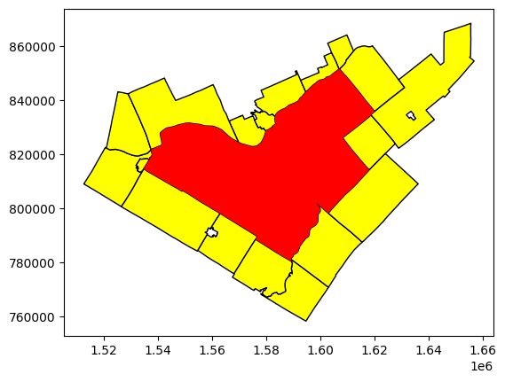

```python
# para metodo queen
base=menor_GADM.iloc[w_queen.neighbors[2713],].plot(facecolor="yellow",edgecolor='k')
menor_GADM.loc[menor_GADM.NAME_2=='Ottawa'].plot(ax=base,facecolor="red")
```

**knn**

```python
menor_GADM.iloc[w_knn20.neighbors[2713] ,]
```

|  | GID_3 | GID_0 | COUNTRY | GID_1 | NAME_1 | NL_NAME_1 | GID_2 | NAME_2 | NL_NAME_2 | NAME_3 | VARNAME_3 | NL_NAME_3 | TYPE_3 | ENGTYPE_3 | CC_3 | HASC_3 | geometry |
| --- | --- | --- | --- | --- | --- | --- | --- | --- | --- | --- | --- | --- | --- | --- | --- | --- | --- |
| 3346 | CAN.11.19.1_1 | CAN | Canada | CAN.11_1 | Québec | NA | CAN.11.19_1 | Communauté-Urbaine-de-l'Outaouai | NA | Aylmer | NA | NA | Ville | Ville | NA | NA | MULTIPOLYGON (((1580023.424 828702.304, 157996... |
| 3349 | CAN.11.19.4_1 | CAN | Canada | CAN.11_1 | Québec | NA | CAN.11.19_1 | Communauté-Urbaine-de-l'Outaouai | NA | Hull | NA | NA | Ville | Ville | NA | NA | MULTIPOLYGON (((1583424.937 834159.215, 158329... |
| 3348 | CAN.11.19.3_1 | CAN | Canada | CAN.11_1 | Québec | NA | CAN.11.19_1 | Communauté-Urbaine-de-l'Outaouai | NA | Gatineau | NA | NA | Ville | Ville | NA | NA | MULTIPOLYGON (((1594697.151 843000.144, 159457... |
| 3947 | CAN.11.63.2_1 | CAN | Canada | CAN.11_1 | Québec | NA | CAN.11.63_1 | Les Collines-de-l'Outaouais | NA | Chelsea | NA | NA | Municipalité | Municipality | NA | NA | MULTIPOLYGON (((1575771.079 832749.821, 157562... |
| 3946 | CAN.11.63.1_1 | CAN | Canada | CAN.11_1 | Québec | NA | CAN.11.63_1 | Les Collines-de-l'Outaouais | NA | Cantley | NA | NA | Municipalité | Municipality | NA | NA | MULTIPOLYGON (((1580989.538 844883.571, 158067... |
| 2612 | CAN.9.26.2_1 | CAN | Canada | CAN.9_1 | Ontario | NA | CAN.9.26_1 | Lanark | NA | Beckwith | NA | NA | Township | Township | NA | NA | MULTIPOLYGON (((1558157.764 790253.978, 155845... |
| 2613 | CAN.9.26.3_1 | CAN | Canada | CAN.9_1 | Ontario | NA | CAN.9.26_1 | Lanark | NA | Carleton Place | NA | NA | Town | Town | NA | NA | MULTIPOLYGON (((1559353.352 792376.267, 155937... |
| 2629 | CAN.9.27.10_1 | CAN | Canada | CAN.9_1 | Ontario | NA | CAN.9.27_1 | Leeds and Grenville | NA | North Grenville | NA | NA | Township | Township | NA | NA | MULTIPOLYGON (((1605927.213 775203.269, 160548... |
| 2779 | CAN.9.41.7_1 | CAN | Canada | CAN.9_1 | Ontario | NA | CAN.9.41_1 | Prescott and Russell | NA | Russell | NA | NA | Township | Township | NA | NA | MULTIPOLYGON (((1618149.828 814194.153, 161786... |
| 3350 | CAN.11.19.5_1 | CAN | Canada | CAN.11_1 | Québec | NA | CAN.11.19_1 | Communauté-Urbaine-de-l'Outaouai | NA | Masson-Angers | NA | NA | Ville | Ville | NA | NA | MULTIPOLYGON (((1606967.254 851487.278, 160681... |
| 2617 | CAN.9.26.7_1 | CAN | Canada | CAN.9_1 | Ontario | NA | CAN.9.26_1 | Lanark | NA | Montague | NA | NA | Township | Township | NA | NA | MULTIPOLYGON (((1568113.605 775753.877, 156811... |
| 2848 | CAN.9.46.3_1 | CAN | Canada | CAN.9_1 | Ontario | NA | CAN.9.46_1 | Stormont, Dundas and Glengarry | NA | North Dundas | NA | NA | Township | Township | NA | NA | MULTIPOLYGON (((1615543.723 787415.214, 161553... |
| 3951 | CAN.11.63.6_1 | CAN | Canada | CAN.11_1 | Québec | NA | CAN.11.63_1 | Les Collines-de-l'Outaouais | NA | Pontiac | NA | NA | Municipalité | Municipality | NA | NA | MULTIPOLYGON (((1569848.222 824350.784, 156983... |
| 2616 | CAN.9.26.6_1 | CAN | Canada | CAN.9_1 | Ontario | NA | CAN.9.26_1 | Lanark | NA | Mississippi Mills | NA | NA | Town | Town | NA | NA | MULTIPOLYGON (((1562965.857 798093.91, 1562154... |
| 3347 | CAN.11.19.2_1 | CAN | Canada | CAN.11_1 | Québec | NA | CAN.11.19_1 | Communauté-Urbaine-de-l'Outaouai | NA | Buckingham | NA | NA | Ville | Ville | NA | NA | MULTIPOLYGON (((1601416.46 856388.1, 1601453.0... |
| 3952 | CAN.11.63.7_1 | CAN | Canada | CAN.11_1 | Québec | NA | CAN.11.63_1 | Les Collines-de-l'Outaouais | NA | Val-des-Monts | NA | NA | Municipalité | Municipality | NA | NA | MULTIPOLYGON (((1591234.317 850923.373, 159077... |
| 3948 | CAN.11.63.3_1 | CAN | Canada | CAN.11_1 | Québec | NA | CAN.11.63_1 | Les Collines-de-l'Outaouais | NA | L'Ange-Gardien | NA | NA | Municipalité | Municipality | NA | NA | MULTIPOLYGON (((1601416.46 856388.1, 1601352.1... |
| 2619 | CAN.9.26.9_1 | CAN | Canada | CAN.9_1 | Ontario | NA | CAN.9.26_1 | Lanark | NA | Smiths Falls | NA | NA | Town | Town | NA | NA | MULTIPOLYGON (((1575539.472 769005.2, 1575437.... |
| 2808 | CAN.9.44.2_1 | CAN | Canada | CAN.9_1 | Ontario | NA | CAN.9.44_1 | Renfrew | NA | Arnprior | NA | NA | Town | Town | NA | NA | MULTIPOLYGON (((1534795.84 814658.656, 1534728... |
| 2628 | CAN.9.27.9_1 | CAN | Canada | CAN.9_1 | Ontario | NA | CAN.9.27_1 | Leeds and Grenville | NA | Merrickville-Wolford | NA | NA | Village | Village | NA | NA | MULTIPOLYGON (((1578566.446 768358.064, 157863... |

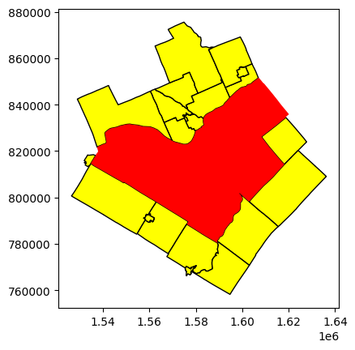

```python
# para metodo knn
base=menor_GADM.iloc[w_knn20.neighbors[2713] ,].plot(facecolor="yellow",edgecolor='k')
menor_GADM.loc[menor_GADM.NAME_2=='Ottawa'].plot(ax=base,facecolor="red")
```

## Ejercicio 7

1. Compute the Moran's coefficient for **one** of your three numeric variables.
2. Make a scatter plot for each variable.

```python
# hacer merge con nivel de contaminacion, # niños en edad escola, etc
# se hace merge con 3 VARIABLES, y solo con una se hace el analisis este de correlacion
```

```python
pd.DataFrame(*w_knn20.full())
```

|  | 0 | 1 | 2 | 3 | 4 | 5 | 6 | 7 | 8 | 9 | ... | 5571 | 5572 | 5573 | 5574 | 5575 | 5576 | 5577 | 5578 | 5579 | 5580 |
| --- | --- | --- | --- | --- | --- | --- | --- | --- | --- | --- | --- | --- | --- | --- | --- | --- | --- | --- | --- | --- | --- |
| 0 | 0.0 | 1.0 | 1.0 | 1.0 | 1.0 | 1.0 | 1.0 | 0.0 | 0.0 | 0.0 | ... | 0.0 | 0.0 | 0.0 | 0.0 | 0.0 | 0.0 | 0.0 | 0.0 | 0.0 | 0.0 |
| 1 | 1.0 | 0.0 | 1.0 | 1.0 | 1.0 | 1.0 | 1.0 | 0.0 | 0.0 | 0.0 | ... | 0.0 | 0.0 | 0.0 | 0.0 | 0.0 | 0.0 | 0.0 | 0.0 | 0.0 | 0.0 |
| 2 | 1.0 | 1.0 | 0.0 | 1.0 | 1.0 | 1.0 | 1.0 | 0.0 | 0.0 | 0.0 | ... | 0.0 | 0.0 | 0.0 | 0.0 | 0.0 | 0.0 | 0.0 | 0.0 | 0.0 | 0.0 |
| 3 | 1.0 | 1.0 | 1.0 | 0.0 | 1.0 | 1.0 | 1.0 | 0.0 | 0.0 | 0.0 | ... | 0.0 | 0.0 | 0.0 | 0.0 | 0.0 | 0.0 | 0.0 | 0.0 | 0.0 | 0.0 |
| 4 | 1.0 | 1.0 | 1.0 | 1.0 | 0.0 | 1.0 | 1.0 | 0.0 | 0.0 | 0.0 | ... | 0.0 | 0.0 | 0.0 | 0.0 | 0.0 | 0.0 | 0.0 | 0.0 | 0.0 | 0.0 |
| ... | ... | ... | ... | ... | ... | ... | ... | ... | ... | ... | ... | ... | ... | ... | ... | ... | ... | ... | ... | ... | ... |
| 5576 | 0.0 | 0.0 | 0.0 | 0.0 | 0.0 | 0.0 | 0.0 | 0.0 | 0.0 | 0.0 | ... | 1.0 | 1.0 | 1.0 | 1.0 | 1.0 | 0.0 | 1.0 | 0.0 | 0.0 | 0.0 |
| 5577 | 0.0 | 0.0 | 0.0 | 0.0 | 0.0 | 0.0 | 0.0 | 0.0 | 0.0 | 0.0 | ... | 1.0 | 1.0 | 1.0 | 1.0 | 1.0 | 1.0 | 0.0 | 0.0 | 0.0 | 0.0 |
| 5578 | 0.0 | 0.0 | 0.0 | 0.0 | 0.0 | 0.0 | 0.0 | 0.0 | 0.0 | 0.0 | ... | 1.0 | 1.0 | 1.0 | 0.0 | 0.0 | 0.0 | 0.0 | 0.0 | 1.0 | 0.0 |
| 5579 | 0.0 | 0.0 | 0.0 | 0.0 | 0.0 | 0.0 | 0.0 | 0.0 | 0.0 | 0.0 | ... | 1.0 | 1.0 | 1.0 | 0.0 | 0.0 | 0.0 | 0.0 | 1.0 | 0.0 | 0.0 |
| 5580 | 0.0 | 0.0 | 0.0 | 0.0 | 0.0 | 0.0 | 0.0 | 0.0 | 0.0 | 0.0 | ... | 0.0 | 0.0 | 0.0 | 0.0 | 0.0 | 0.0 | 0.0 | 1.0 | 1.0 | 0.0 |

5581 rows × 5581 columns

```python
w_knn20.transform = 'R'
```

```python
pd.DataFrame(*w_knn20.full()).sum(axis=1)
```

|  | 0 |
| --- | --- |
| 0 | 1.0 |
| 1 | 1.0 |
| 2 | 1.0 |
| 3 | 1.0 |
| 4 | 1.0 |
| ... | ... |
| 5576 | 1.0 |
| 5577 | 1.0 |
| 5578 | 1.0 |
| 5579 | 1.0 |
| 5580 | 1.0 |

5581 rows × 1 columns

**dtype:** float64

```python
!pip install esda
```

```python
w_knn8 = KNN.from_dataframe(data, k=8)
```

**IDH**

```python
from esda.moran import Moran

moranIDH = Moran(data['IDH_2022'], w_knn8)
moranIDH.I,moranIDH.p_sim
# se muestra que casi no hay correlación y que este resultado no es coincidencia. Esto se debe a que
# estamos trabajando con muy poca data
```

```
(np.float64(0.0552915250637212), np.float64(0.04))
```

```python
!pip install splot
```

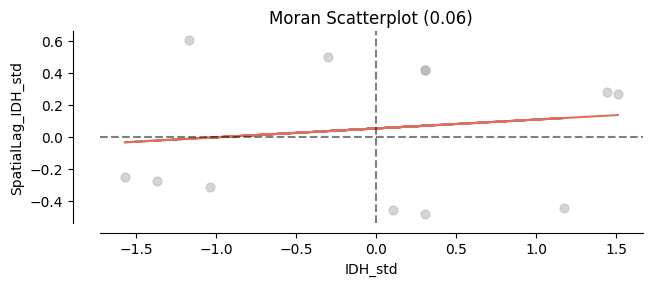

```python
from splot.esda import moran_scatterplot

fig, ax = moran_scatterplot(moranIDH, aspect_equal=True)
ax.set_xlabel('IDH_std')
ax.set_ylabel('SpatialLag_IDH_std');
```

**PBI**

```python
moranPBI = Moran(data['GDPperCapita_2023'], w_knn8)
moranPBI.I,moranPBI.p_sim
```

```
(np.float64(0.17491730909895079), np.float64(0.006))
```

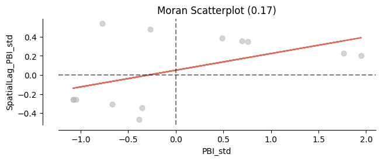

```python
fig, ax = moran_scatterplot(moranPBI, aspect_equal=True)
ax.set_xlabel('PBI_std')
ax.set_ylabel('SpatialLag_PBI_std');
```

**HomRate**

```python
moranHomRate = Moran(data['HomicideRate_2023'], w_knn8)
moranHomRate.I,moranHomRate.p_sim
```

```
(np.float64(0.13839147448544573), np.float64(0.002))
```

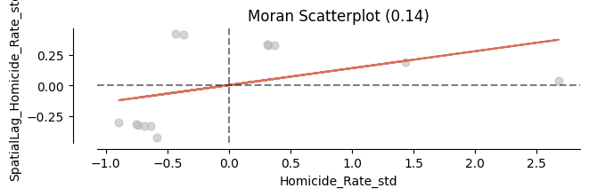

```python
fig, ax = moran_scatterplot(moranHomRate, aspect_equal=True)
ax.set_xlabel('Homicide_Rate_std')
ax.set_ylabel('SpatialLag_Homicide_Rate_std');
```

## Ejercicio 8

1. Compute the Local Moran for the variables in your data that have significant spatial correlation.
2. Create a new column for each of those variables, with a label ('0 no_sig', '1 hotSpot', '2 coldOutlier', '3 coldSpot', '4 hotOutlier').
3. Prepare a map for each of the variables analyzed, showing the spots and outliers.

**IDH**

```python
from esda.moran import Moran_Local
lisaIDH = Moran_Local(y=data['IDH_2022'], w=w_knn8,seed=2022)
```

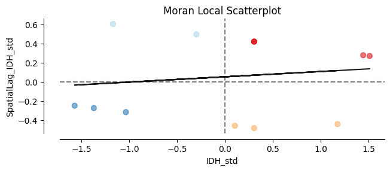

```python
fig, ax = moran_scatterplot(lisaIDH,p=0.05)
ax.set_xlabel('IDH_std')
ax.set_ylabel('SpatialLag_IDH_std');
```

```python
data['IDH_quadrant']=[l if p <0.05 else 0 for l,p in zip(lisaIDH.q,lisaIDH.p_sim)]
data['IDH_quadrant'].value_counts()
```

| IDH_quadrant | count |
| --- | --- |
| 1 | 5 |
| 3 | 3 |
| 4 | 3 |
| 2 | 2 |

**dtype:** int64

```python
labels = ['1 hotSpot', '2 coldOutlier', '3 coldSpot', '4 hotOutlier']
data['IDH_quadrant_names']=[labels[i-1] for i in data['IDH_quadrant']]
data['IDH_quadrant_names'].value_counts()
```

| IDH_quadrant_names | count |
| --- | --- |
| 1 hotSpot | 5 |
| 3 coldSpot | 3 |
| 4 hotOutlier | 3 |
| 2 coldOutlier | 2 |

**dtype:** int64

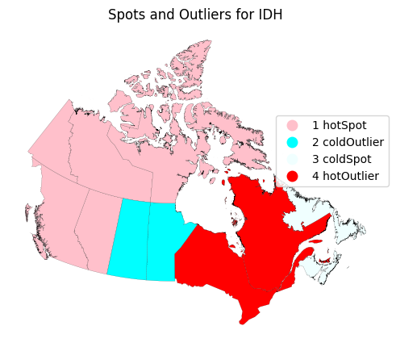

```python
import matplotlib.pyplot as plt
from matplotlib import colors
myColMap = colors.ListedColormap(['pink', 'cyan', 'azure','red'])

f, ax = plt.subplots(1, figsize=(6,6))
# Plot unique values choropleth including
# a legend and with no boundary lines

plt.title('Spots and Outliers for IDH')

data.plot(column='IDH_quadrant_names',
                categorical=True,
                cmap=myColMap,
                linewidth=0.1,
                edgecolor='k',
                legend=True,
                legend_kwds={'loc': 'center left',
                             'bbox_to_anchor': (0.7, 0.6)},
                ax=ax)
# Remove axis
ax.set_axis_off()
# Display the map
plt.show()
```

**PBI**

```python
from esda.moran import Moran_Local
lisaPBI = Moran_Local(y=data['GDPperCapita_2023'], w=w_knn8,seed=2022)
```

```python
data['PBI_quadrant']=[l if p <0.05 else 0 for l,p in zip(lisaPBI.q,lisaPBI.p_sim)]
data['PBI_quadrant'].value_counts()
```

| PBI_quadrant | count |
| --- | --- |
| 1 | 5 |
| 0 | 5 |
| 2 | 2 |
| 3 | 1 |

**dtype:** int64

```python
labels = ["0 no_sig",'1 hotSpot', '2 coldOutlier', '3 coldSpot', '4 hotOutlier']
data['PBI_quadrant_names']=[labels[i] for i in data['PBI_quadrant']]
data['PBI_quadrant_names'].value_counts()
```

| PBI_quadrant_names | count |
| --- | --- |
| 1 hotSpot | 5 |
| 0 no_sig | 5 |
| 2 coldOutlier | 2 |
| 3 coldSpot | 1 |

**dtype:** int64

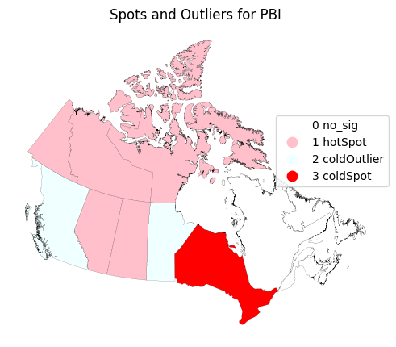

```python
import matplotlib.pyplot as plt
from matplotlib import colors
myColMap = colors.ListedColormap(['white','pink', 'cyan', 'azure','red'])

f, ax = plt.subplots(1, figsize=(6,6))

plt.title('Spots and Outliers for PBI')

data.plot(column='PBI_quadrant_names',
                categorical=True,
                cmap=myColMap,
                linewidth=0.1,
                edgecolor='k',
                legend=True,
                legend_kwds={'loc': 'center left',
                             'bbox_to_anchor': (0.7, 0.6)},
                ax=ax)
# Remove axis
ax.set_axis_off()
# Display the map
plt.show()
```

**Homicide Rate**

```python
from esda.moran import Moran_Local
lisaHomRate = Moran_Local(y=data['HomicideRate_2023'], w=w_knn8,seed=2022)
```

```python
data['HomRate_quadrant']=[l if p <0.05 else 0 for l,p in zip(lisaHomRate.q,lisaHomRate.p_sim)]
data['HomRate_quadrant'].value_counts()
```

| HomRate_quadrant | count |
| --- | --- |
| 1 | 5 |
| 0 | 5 |
| 2 | 2 |
| 3 | 1 |

**dtype:** int64

```python
labels = ["0 no_sig",'1 hotSpot', '2 coldOutlier', '3 coldSpot', '4 hotOutlier']
data['HomRate_quadrant_names']=[labels[i] for i in data['HomRate_quadrant']]
data['HomRate_quadrant_names'].value_counts()
```

| HomRate_quadrant_names | count |
| --- | --- |
| 1 hotSpot | 5 |
| 0 no_sig | 5 |
| 2 coldOutlier | 2 |
| 3 coldSpot | 1 |

**dtype:** int64

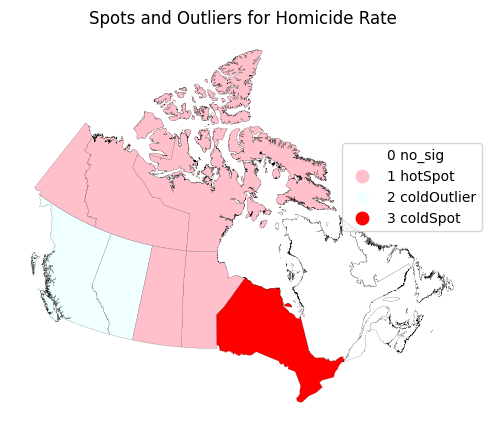

```python
myColMap = colors.ListedColormap([ 'white', 'pink', 'cyan', 'azure','red'])

f, ax = plt.subplots(1, figsize=(6,6))

plt.title('Spots and Outliers for Homicide Rate')

data.plot(column='HomRate_quadrant_names',
                categorical=True,
                cmap=myColMap,
                linewidth=0.1,
                edgecolor='k',
                legend=True,
                legend_kwds={'loc': 'center left',
                             'bbox_to_anchor': (0.7, 0.6)},
                ax=ax)
# Remove axis
ax.set_axis_off()
# Display the map
plt.show()
```

## Ejercicio 9

Use your three variables to carry out the cluster/regional analysis.

```python
data.head()
```

|  | COUNTRY | PROVINCIA | geometry | IDH_2022 | Poblacion | GDPperCapita_2023 | HomicideRate_2023 | IDH_quadrant | IDH_quadrant_names | PBI_quadrant | PBI_quadrant_names | HomRate_quadrant | HomRate_quadrant_names |
| --- | --- | --- | --- | --- | --- | --- | --- | --- | --- | --- | --- | --- | --- |
| 0 | CANADA | ALBERTA | MULTIPOLYGON (((-1191696.513 1131094.24, -1193... | 0.947 | 4684514 | 96576 | 2.45 | 1 | 1 hotSpot | 1 | 1 hotSpot | 2 | 2 coldOutlier |
| 1 | CANADA | BRITISH COLUMBIA | MULTIPOLYGON (((-1994216.432 1323427.567, -199... | 0.946 | 5531553 | 74099 | 2.23 | 1 | 1 hotSpot | 2 | 2 coldOutlier | 2 | 2 coldOutlier |
| 2 | CANADA | MANITOBA | MULTIPOLYGON (((-225729.524 989985.252, -22714... | 0.907 | 1454743 | 63153 | 5.09 | 2 | 2 coldOutlier | 2 | 2 coldOutlier | 1 | 1 hotSpot |
| 3 | CANADA | NEW BRUNSWICK | MULTIPOLYGON (((2280813.977 989844.48, 2280788... | 0.904 | 832190 | 56520 | 1.08 | 3 | 3 coldSpot | 0 | 0 no_sig | 0 | 0 no_sig |
| 4 | CANADA | NEWFOUNDLAND AND LABRADOR | MULTIPOLYGON (((3062487.374 1723165.753, 30624... | 0.901 | 538907 | 72293 | 1.49 | 3 | 3 coldSpot | 0 | 0 no_sig | 0 | 0 no_sig |

```python
selected_variables = ['GDPperCapita_2023','HomicideRate_2023','IDH_2022']
```

```python
data[selected_variables].corr()
```

|  | GDPperCapita_2023 | HomicideRate_2023 | IDH_2022 |
| --- | --- | --- | --- |
| GDPperCapita_2023 | 1.000000 | 0.761963 | 0.396979 |
| HomicideRate_2023 | 0.761963 | 1.000000 | 0.104080 |
| IDH_2022 | 0.396979 | 0.104080 | 1.000000 |

```python
import seaborn as sea
```

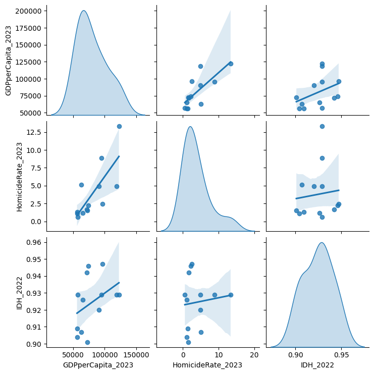

```python
sea.pairplot(data[selected_variables], kind="reg", diag_kind="kde")
```

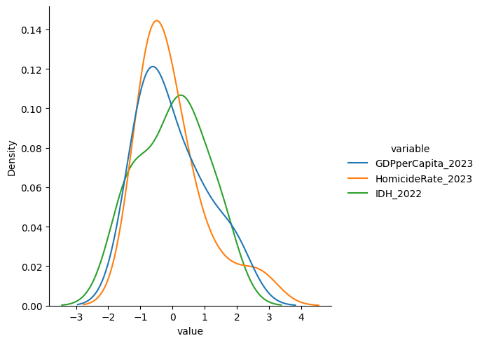

```python
# hay que invertir Homicide Rate porque se espera que a mayor IDH o GDP, el Homicide Rate sea menor
from sklearn.preprocessing import StandardScaler


scaler = StandardScaler()
normalized_data = scaler.fit_transform(data[selected_variables])
sea.displot(pd.melt(pd.DataFrame(normalized_data,columns=selected_variables)),
            x="value", hue="variable",kind="kde",
            log_scale=(False,False))
```

```python
# new names
selected_variables_new_std=[s+'_std' for s in selected_variables]

# add colunms
data[selected_variables_new_std]=normalized_data
```

```python
data.head()
```

|  | COUNTRY | PROVINCIA | geometry | IDH_2022 | Poblacion | GDPperCapita_2023 | HomicideRate_2023 | IDH_quadrant | IDH_quadrant_names | PBI_quadrant | PBI_quadrant_names | HomRate_quadrant | HomRate_quadrant_names | GDPperCapita_2023_std | HomicideRate_2023_std | IDH_2022_std |
| --- | --- | --- | --- | --- | --- | --- | --- | --- | --- | --- | --- | --- | --- | --- | --- | --- |
| 0 | CANADA | ALBERTA | MULTIPOLYGON (((-1191696.513 1131094.24, -1193... | 0.947 | 4684514 | 96576 | 2.45 | 1 | 1 hotSpot | 1 | 1 hotSpot | 2 | 2 coldOutlier | 0.756766 | -0.370997 | 1.509748 |
| 1 | CANADA | BRITISH COLUMBIA | MULTIPOLYGON (((-1994216.432 1323427.567, -199... | 0.946 | 5531553 | 74099 | 2.23 | 1 | 1 hotSpot | 2 | 2 coldOutlier | 2 | 2 coldOutlier | -0.271396 | -0.432543 | 1.442762 |
| 2 | CANADA | MANITOBA | MULTIPOLYGON (((-225729.524 989985.252, -22714... | 0.907 | 1454743 | 63153 | 5.09 | 2 | 2 coldOutlier | 2 | 2 coldOutlier | 1 | 1 hotSpot | -0.772097 | 0.367554 | -1.169668 |
| 3 | CANADA | NEW BRUNSWICK | MULTIPOLYGON (((2280813.977 989844.48, 2280788... | 0.904 | 832190 | 56520 | 1.08 | 3 | 3 coldSpot | 0 | 0 no_sig | 0 | 0 no_sig | -1.075509 | -0.754260 | -1.370624 |
| 4 | CANADA | NEWFOUNDLAND AND LABRADOR | MULTIPOLYGON (((3062487.374 1723165.753, 30624... | 0.901 | 538907 | 72293 | 1.49 | 3 | 3 coldSpot | 0 | 0 no_sig | 0 | 0 no_sig | -0.354007 | -0.639561 | -1.571580 |
| 5 | CANADA | NORTHWEST TERRITORIES | MULTIPOLYGON (((-932976.987 3668489.676, -9330... | 0.929 | 44681 | 122602 | 13.34 | 1 | 1 hotSpot | 1 | 1 hotSpot | 1 | 1 hotSpot | 1.947269 | 2.675526 | 0.304011 |
| 6 | CANADA | NOVA SCOTIA | MULTIPOLYGON (((2419990.709 926493.096, 242000... | 0.909 | 1056486 | 56389 | 1.32 | 3 | 3 coldSpot | 0 | 0 no_sig | 0 | 0 no_sig | -1.081502 | -0.687119 | -1.035697 |
| 7 | CANADA | NUNAVUT | MULTIPOLYGON (((1581589.008 2742840.281, 15815... | 0.929 | 40700 | 118550 | 4.92 | 1 | 1 hotSpot | 1 | 1 hotSpot | 1 | 1 hotSpot | 1.761919 | 0.319996 | 0.304011 |
| 8 | CANADA | ONTARIO | MULTIPOLYGON (((1409005.46 492629.458, 1408574... | 0.942 | 15623207 | 71659 | 1.68 | 4 | 4 hotOutlier | 3 | 3 coldSpot | 3 | 3 coldSpot | -0.383008 | -0.586408 | 1.174821 |
| 9 | CANADA | PRINCE EDWARD ISLAND | MULTIPOLYGON (((2505095.555 1289997.862, 25051... | 0.929 | 173713 | 57129 | 0.58 | 4 | 4 hotOutlier | 0 | 0 no_sig | 0 | 0 no_sig | -1.047652 | -0.894137 | 0.304011 |
| 10 | CANADA | QUEBEC | MULTIPOLYGON (((1678607.031 812858.207, 167861... | 0.926 | 8848020 | 65490 | 1.14 | 4 | 4 hotOutlier | 0 | 0 no_sig | 0 | 0 no_sig | -0.665196 | -0.737475 | 0.103054 |
| 11 | CANADA | SASKATCHEWAN | MULTIPOLYGON (((-479648.471 1008211.632, -4796... | 0.920 | 1209307 | 90715 | 4.88 | 2 | 2 coldOutlier | 1 | 1 hotSpot | 1 | 1 hotSpot | 0.488667 | 0.308806 | -0.298858 |
| 12 | CANADA | YUKON | MULTIPOLYGON (((-1485495.114 2531187.928, -148... | 0.929 | 45463 | 95242 | 8.89 | 1 | 1 hotSpot | 1 | 1 hotSpot | 1 | 1 hotSpot | 0.695745 | 1.430620 | 0.304011 |

```python
data['HomicideRate_Inverso_2023_std']=-1*data.HomicideRate_2023_std
```

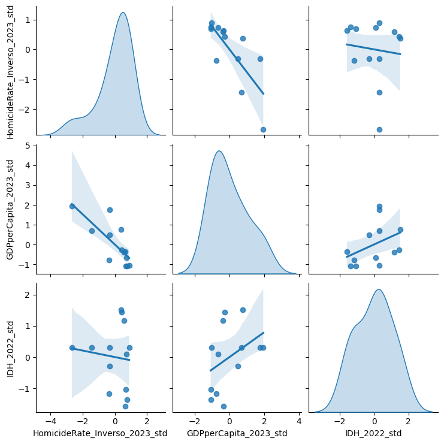

```python
# as a result:
selected_variables_new_std = ['HomicideRate_Inverso_2023_std',
                     'GDPperCapita_2023_std',
                     'IDH_2022_std']
sea.pairplot(
    data[selected_variables_new_std], kind="reg", diag_kind="kde"
)
```

**Conventinoal clustering**

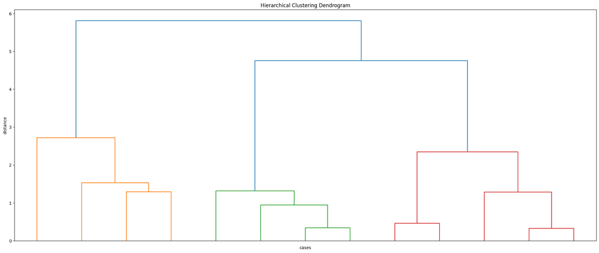

```python
from scipy.cluster import hierarchy as hc


Z = hc.linkage(data[selected_variables_new_std], 'ward')
# calculate full dendrogram
plt.figure(figsize=(25, 10))
plt.title('Hierarchical Clustering Dendrogram')
plt.xlabel('cases')
plt.ylabel('distance')
hc.dendrogram(
    Z,
    leaf_rotation=90.,  # rotates the x axis labels
    leaf_font_size=1,  # font size for the x axis labels
)
plt.show()
```

```python
from sklearn.cluster import AgglomerativeClustering as agnes

import numpy as np
np.random.seed(12345)# Set seed for reproducibility

# Initialize the algorithm, requesting 3 clusters
model = agnes(linkage="ward", n_clusters=3).fit(data[selected_variables_new_std])

# Assign labels to main data table
data["hc_ag3"] = model.labels_
```

```python
data["hc_ag3"].value_counts()
```

| hc_ag3 | count |
| --- | --- |
| 1 | 5 |
| 2 | 4 |
| 0 | 4 |

**dtype:** int64

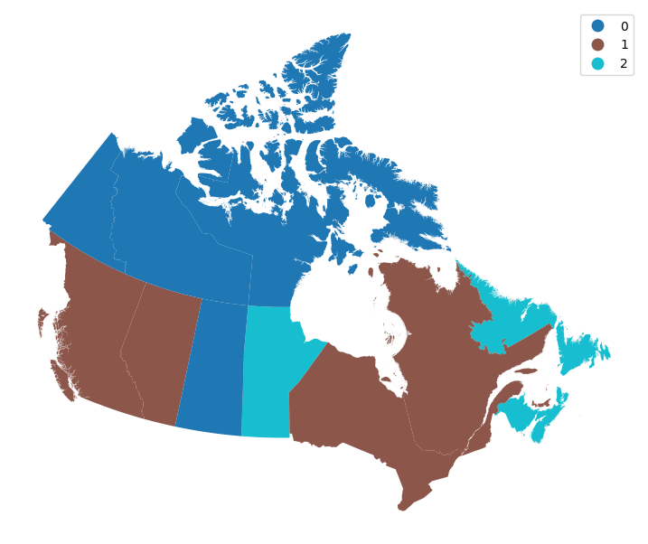

```python
# Set up figure and ax
f, ax = plt.subplots(1, figsize=(9, 9))
# Plot unique values choropleth including
# a legend and with no boundary lines
data.plot(
    column="hc_ag3", categorical=True, legend=True, linewidth=0, ax=ax
)
# Remove axis
ax.set_axis_off()
# Display the map
plt.show()
```

**Regionalized clustering**

```python
w_queen = Queen.from_dataframe(data,use_index=False)
```

```python
model_queen = agnes(linkage="ward", n_clusters=3, connectivity=w_queen.sparse).fit(data[selected_variables_new_std])
data["hc_ag3_wQueen"] = model_queen.labels_
```

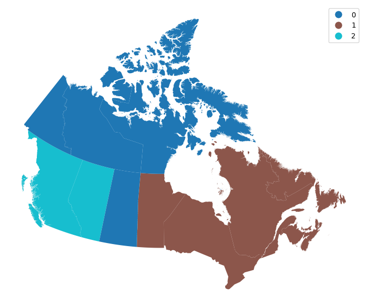

```python
# Set up figure and ax
f, ax = plt.subplots(1, figsize=(9, 9))
# Plot unique values choropleth including a legend and with no boundary lines
data.plot(
    column="hc_ag3_wQueen",
    categorical=True,
    legend=True,
    linewidth=0,
    ax=ax,
)
# Remove axis
ax.set_axis_off()
# Display the map
plt.show()
```

```python
# para ver qué clustering es el más adecuado, podemos ver la compacidad de cada método
from esda import shape as shapestats
results={}
for cluster_type in ("hc_ag3_wQueen", "hc_ag3"):
    # compute the region polygons using a dissolve
    regions = data[[cluster_type, "geometry"]].to_crs("ESRI:102001").dissolve(by=cluster_type)
    # compute the actual convex hull quotient for these regions
    chullr = shapestats.convex_hull_ratio(regions)
    # cast to a dataframe
    result = {cluster_type:chullr}
    results.update(result)
# stack the series together along columns
pd.DataFrame(results)
```

|  | hc_ag3_wQueen | hc_ag3 |
| --- | --- | --- |
| 0 | 0.494340 | 0.494340 |
| 1 | 0.601777 | 0.462117 |
| 2 | 0.828507 | 0.223788 |

```python
# segun este criterio, se puede decir que spatial clustering fue más efectivo para Canada
```

```python
from sklearn import metrics

fit_scores = []
for cluster_type in ("hc_ag3_wQueen", "hc_ag3"):
    # compute the CH score
    ch_score = metrics.calinski_harabasz_score(
        # using scaled variables
        data[selected_variables_new_std],
        # using these labels
        data[cluster_type],
    )
    sil_score = metrics.silhouette_score(
        # using scaled variables
        data[selected_variables_new_std],
        # using these labels
        data[cluster_type],
    )
    # and append the cluster type with the CH score
    fit_scores.append((cluster_type, ch_score,sil_score))


# re-arrange the scores into a dataframe for display
pd.DataFrame(
    fit_scores, columns=["cluster type", "CH score", "SIL score"]
).set_index("cluster type")
```

| cluster type | CH score | SIL score |
| --- | --- | --- |
| hc_ag3_wQueen | 8.581915 | 0.293870 |
| hc_ag3 | 13.048216 | 0.428276 |

```python
# segun este criterio, el clustering convencional es el más adecuado
```

## Ejercicio 10

Use your three variables to carry out regression analysis (conventional and spatial).

```python
!pip install pysal
```

[output not shown]

```python
data.head()
```

|  | COUNTRY | PROVINCIA | geometry | IDH_2022 | Poblacion | GDPperCapita_2023 | HomicideRate_2023 | IDH_quadrant | IDH_quadrant_names | PBI_quadrant | PBI_quadrant_names | HomRate_quadrant | HomRate_quadrant_names | GDPperCapita_2023_std | HomicideRate_2023_std | IDH_2022_std | HomicideRate_Inverso_2023_std | hc_ag3 | hc_ag3_wQueen |
| --- | --- | --- | --- | --- | --- | --- | --- | --- | --- | --- | --- | --- | --- | --- | --- | --- | --- | --- | --- |
| 0 | CANADA | ALBERTA | MULTIPOLYGON (((-1191696.513 1131094.24, -1193... | 0.947 | 4684514 | 96576 | 2.45 | 1 | 1 hotSpot | 1 | 1 hotSpot | 2 | 2 coldOutlier | 0.756766 | -0.370997 | 1.509748 | 0.370997 | 1 | 2 |
| 1 | CANADA | BRITISH COLUMBIA | MULTIPOLYGON (((-1994216.432 1323427.567, -199... | 0.946 | 5531553 | 74099 | 2.23 | 1 | 1 hotSpot | 2 | 2 coldOutlier | 2 | 2 coldOutlier | -0.271396 | -0.432543 | 1.442762 | 0.432543 | 1 | 2 |
| 2 | CANADA | MANITOBA | MULTIPOLYGON (((-225729.524 989985.252, -22714... | 0.907 | 1454743 | 63153 | 5.09 | 2 | 2 coldOutlier | 2 | 2 coldOutlier | 1 | 1 hotSpot | -0.772097 | 0.367554 | -1.169668 | -0.367554 | 2 | 1 |
| 3 | CANADA | NEW BRUNSWICK | MULTIPOLYGON (((2280813.977 989844.48, 2280788... | 0.904 | 832190 | 56520 | 1.08 | 3 | 3 coldSpot | 0 | 0 no_sig | 0 | 0 no_sig | -1.075509 | -0.754260 | -1.370624 | 0.754260 | 2 | 1 |
| 4 | CANADA | NEWFOUNDLAND AND LABRADOR | MULTIPOLYGON (((3062487.374 1723165.753, 30624... | 0.901 | 538907 | 72293 | 1.49 | 3 | 3 coldSpot | 0 | 0 no_sig | 0 | 0 no_sig | -0.354007 | -0.639561 | -1.571580 | 0.639561 | 2 | 1 |

```python
from pysal.model import spreg

dep_var_name=['HomicideRate_2023']
ind_vars_names=['GDPperCapita_2023','IDH_2022']
labels=['Homicide Rate %','GDP per capita', 'Indice desarrollo humano %']

ols_model = spreg.OLS(
    # Dependent variable
    data[dep_var_name].values,
    # Independent variables
    data[ind_vars_names].values,
    # Dependent variable name
    name_y=labels[0],
    # Independent variable name
    name_x=labels[1:],
    name_ds='data')

print(ols_model.summary)
```

```
REGRESSION RESULTS
------------------

SUMMARY OF OUTPUT: ORDINARY LEAST SQUARES
-----------------------------------------
Data set            :        data
Weights matrix      :        None
Dependent Variable  :Homicide Rate %                Number of Observations:          13
Mean dependent var  :      3.7762                Number of Variables   :           3
S.D. dependent var  :      3.7205                Degrees of Freedom    :          10
R-squared           :      0.6273
Adjusted R-squared  :      0.5528
Sum squared residual:     61.9058                F-statistic           :      8.4162
Sigma-square        :       6.191                Prob(F-statistic)     :     0.00719
S.E. of regression  :       2.488                Log likelihood        :     -28.591
Sigma-square ML     :       4.762                Akaike info criterion :      63.181
S.E of regression ML:      2.1822                Schwarz criterion     :      64.876

------------------------------------------------------------------------------------
            Variable     Coefficient       Std.Error     t-Statistic     Probability
------------------------------------------------------------------------------------
            CONSTANT        44.71528        45.54150         0.98186         0.34933
      GDP per capita         0.00014         0.00003         4.06715         0.00226
Indice desarrollo humano %       -56.39365        50.36316        -1.11974         0.28900
------------------------------------------------------------------------------------

REGRESSION DIAGNOSTICS
MULTICOLLINEARITY CONDITION NUMBER         162.176

TEST ON NORMALITY OF ERRORS
TEST                             DF        VALUE           PROB
Jarque-Bera                       2          0.224           0.8939

DIAGNOSTICS FOR HETEROSKEDASTICITY
RANDOM COEFFICIENTS
TEST                             DF        VALUE           PROB
Breusch-Pagan test                2          7.276           0.0263
Koenker-Bassett test              2         10.290           0.0058
================================ END OF REPORT =====================================
```